# Statistical Analysis of Designs with Repeated Measures by Mixed Models

Livio Finos

# 1 Motivation

## 1.1 Import

```r
load("./dataset/datiEEG_LMM_2x2.Rdata")
summary(dati)
```

```
##       Subj     Chan     Condition       Y
##  s01    : 16   O1:160   f:160     Min.   :-9.9964
##  s02    : 16   O2:160   n:160     1st Qu.:-2.5505
##  s03    : 16                      Median :-0.8299
##  s04    : 16                      Mean   :-0.6867
##  s05    : 16                      3rd Qu.: 1.3913
##  s06    : 16                      Max.   : 5.5468
##  (Other):224
```

## 1.2 EDA

For `Y`: P300 Average Amplitude

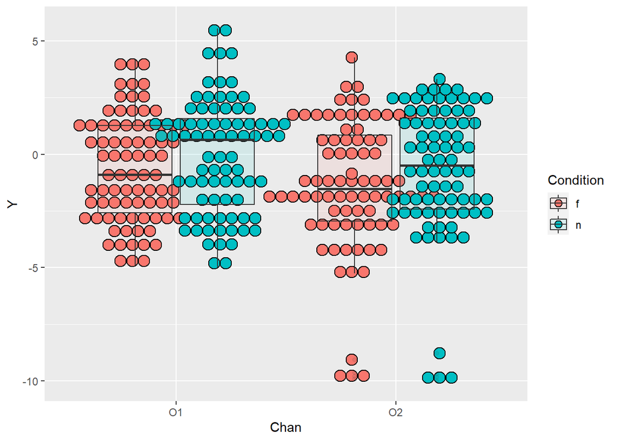

```r
library(ggplot2)
p <- ggplot(dati,aes(x=Chan,y=Y,fill=Condition))
p=p+geom_dotplot(binaxis = "y",position=position_dodge(0.8),stackdir = "center") +geom_boxplot(alpha=.1)
p
```

Is there a specificity of the Subject?

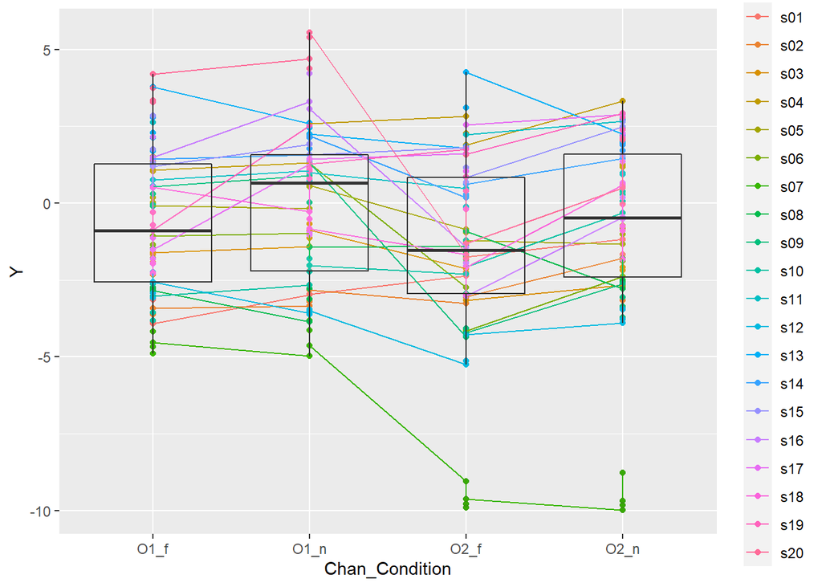

```r
dati$Chan_Condition=paste(sep = "_",dati$Chan,dati$Condition)

p <- ggplot(dati,aes(x=Chan_Condition,y=Y))
p+geom_point(aes(group = Subj, colour = Subj))+
  geom_line(aes(group = Subj, colour = Subj))+
   geom_boxplot(alpha=.1)
```

We subtract the Subject-specific effect (i.e. Subject’s mean) to each observation.

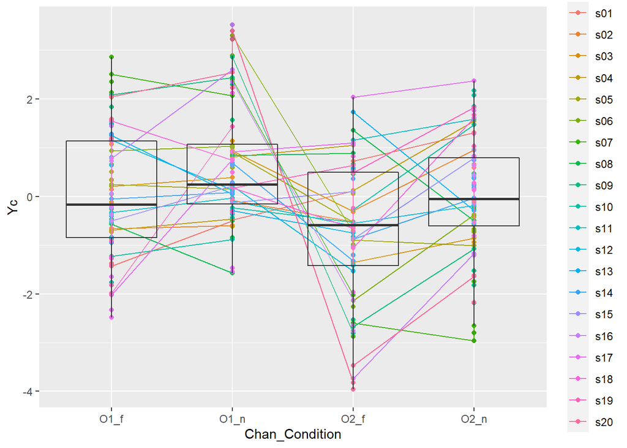

```r
mod=lm(Y~Subj,data=dati)
# summary(mod)
Y=residuals(mod)
dati$Yc=as.vector(Y)



library(ggplot2)
p <- ggplot(dati,aes(Chan_Condition,Yc))
p+geom_point(aes(group = Subj, colour = Subj))+
  geom_line(aes(group = Subj, colour = Subj))+
   geom_boxplot(alpha=.1)
```

The dispersion of the data has been largely reduced. This effect is the one taken in account by the models for repeated measures.

# 2 Mixed models

## 2.1 IMPORTANT REMARK about contrasts in (mixed) linear models

```r
# VERY IMPORTANT:
contrasts(dati$Condition) <- contr.sum(2) #2 is the number of levels
contrasts(dati$Chan) <- contr.sum(2) #2 is the number of levels
```

## 2.2 Intuition

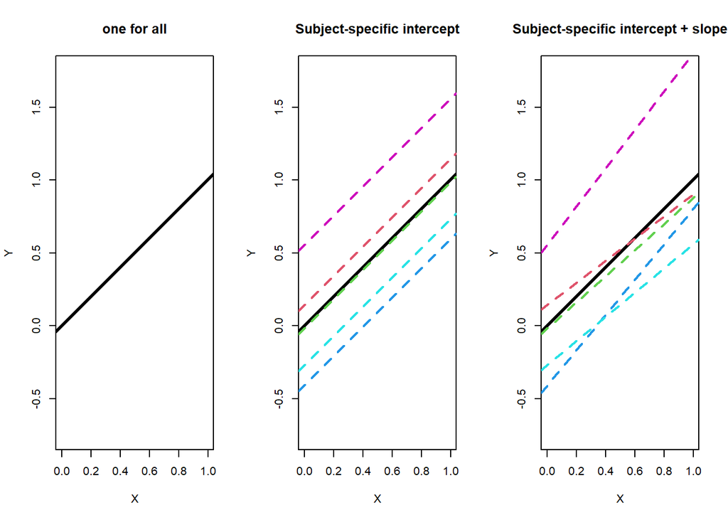

Mixed models allow to model Subject-specific (average) effect by assuming that it is randomly drawn from the dstribution of the population (which is normal).

I assume you are expert on mixed models, if not https://en.wikipedia.org/wiki/Mixed_model  
and much more on: http://webcom.upmf-grenoble.fr/LIP/Perso/DMuller/M2R/R_et_Mixed/documents/Bates-book.pdf  
and  
https://cran.r-project.org/web/packages/lme4/vignettes/lmer.pdf

Due to the small size of the dataset, in our example we only explore the scenario with random intercept and fixed slope (i.e. a simpler model, less parameters).

## 2.3 The model

Models with random effects can be defined as:
$$Y_{n\times 1} = X_{n\times p} B_{p\times 1} + Z_{n\times q} b_{q\times 1} + \varepsilon_{n\times 1}$$

where
$$\varepsilon\sim\mathcal{N}( 0,\sigma^2 I_n)$$

In the models we will consider, the random effects are modeled as a multivariate normal random variable:
$$b\sim\mathcal{N}(0,\Sigma_{q\times q}),$$

In a *linear mixed model* the Conditional distribution $(Y|\mathcal B=b)$ is a *spherical* multivariate Gaussian.

**Random effect for Subject (Random Intercept)**

$Z$ is the matrix of dummy variables of the column `dati$Subj`.

```r
library(lmerTest)

mod=lmer(Y~ Condition*Chan +(1|Subj),data=dati)

summary(mod)
```

```
## Linear mixed model fit by REML. t-tests use Satterthwaite's method [
## lmerModLmerTest]
## Formula: Y ~ Condition * Chan + (1 | Subj)
##    Data: dati
##
## REML criterion at convergence: 1165
##
## Scaled residuals:
##      Min       1Q   Median       3Q      Max
## -2.45740 -0.57314 -0.04347  0.69734  2.21259
##
## Random effects:
##  Groups   Name        Variance Std.Dev.
##  Subj     (Intercept) 5.647    2.376
##  Residual             1.709    1.307
## Number of obs: 320, groups:  Subj, 20
##
## Fixed effects:
##                   Estimate Std. Error        df t value Pr(>|t|)
## (Intercept)       -0.68675    0.53639  19.00000  -1.280    0.216
## Condition1        -0.32723    0.07309 297.00000  -4.477 1.08e-05 ***
## Chan1              0.34713    0.07309 297.00000   4.749 3.18e-06 ***
## Condition1:Chan1   0.02160    0.07309 297.00000   0.295    0.768
## ---
## Signif. codes:  0 '***' 0.001 '**' 0.01 '*' 0.05 '.' 0.1 ' ' 1
##
## Correlation of Fixed Effects:
##             (Intr) Cndtn1 Chan1
## Condition1  0.000
## Chan1       0.000  0.000
## Cndtn1:Chn1 0.000  0.000  0.000
```

```r
car::Anova(mod,type=3)
```

```
## Analysis of Deviance Table (Type III Wald chisquare tests)
##
## Response: Y
##                  Chisq Df Pr(>Chisq)
## (Intercept)     1.6392  1     0.2004
## Condition      20.0447  1  7.565e-06 ***
## Chan           22.5567  1  2.040e-06 ***
## Condition:Chan  0.0873  1     0.7676
## ---
## Signif. codes:  0 '***' 0.001 '**' 0.01 '*' 0.05 '.' 0.1 ' ' 1
```

## 2.4 Plotting tools

for the first model:

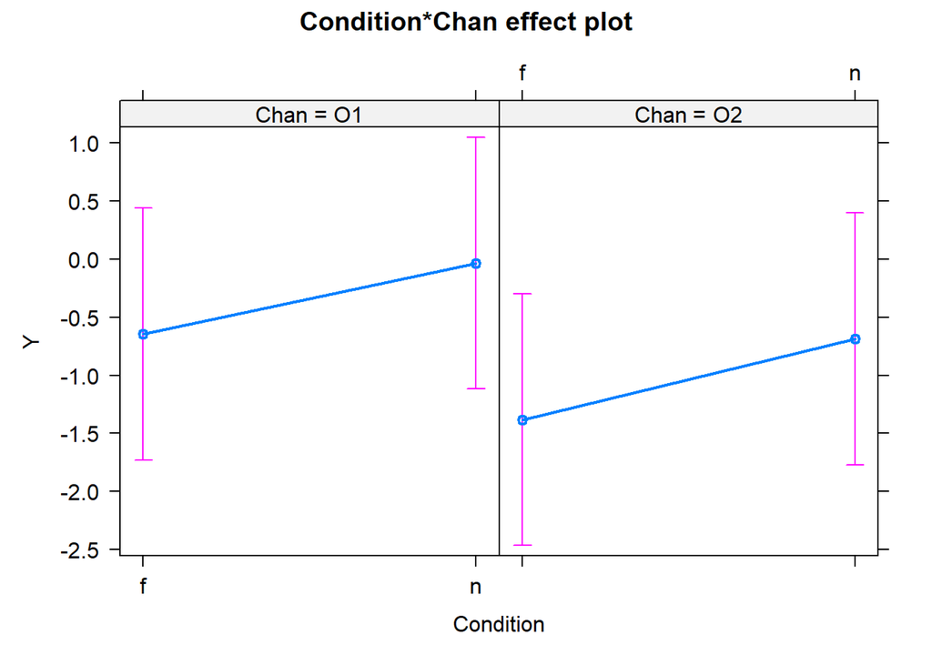

```r
library(effects)
plot(allEffects(mod))
```

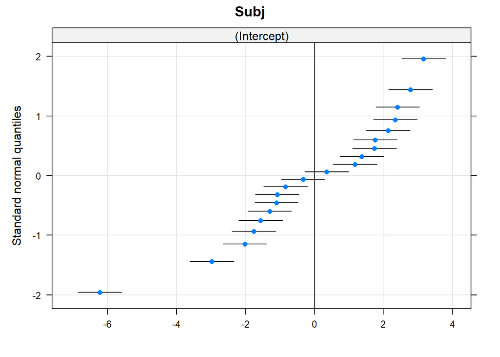

```r
#plot random effects:
require(lattice)
qqmath(ranef(mod, condVar=TRUE))
```

An alternative plotting tool:

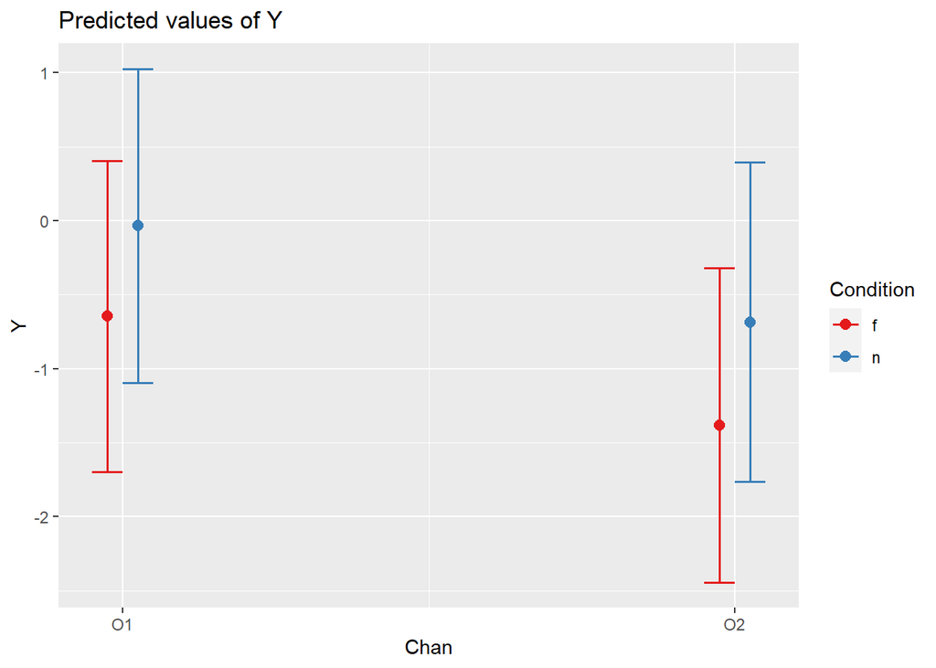

```r
library(sjPlot)
library(ggplot2)
plot_model(mod, type = "pred", terms = c("Chan","Condition"))
```

## 2.5 Validity of the assumptions

- Independence of the residuals?
- Normality of the residuals?
- Homoscedasticity of the residuals (i.e. same variance between Subject/Condition/Chan?
- outliers?
- Leaverage? (influential observations)

Please, do not test for normality, for homoscedasticity, sphericity etc.

Use Exploratory data Analysis, instead!

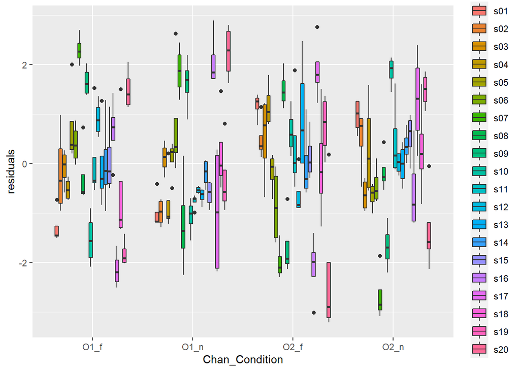

```r
dati$residuals=residuals(mod)
p <- ggplot(dati, aes(x=Chan_Condition, y=residuals,fill=Subj)) +   geom_boxplot()
p
```

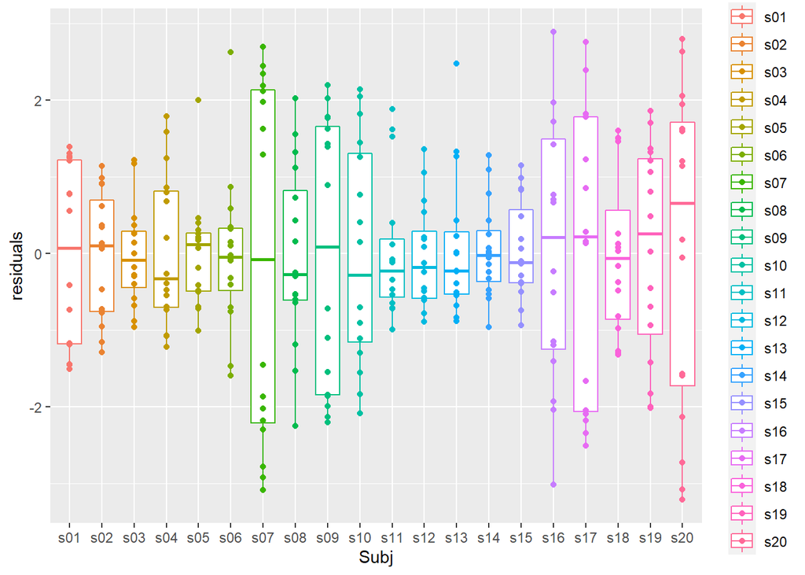

```r
p <- ggplot(dati, aes(x=Subj, y=residuals,col=Subj)) +   geom_boxplot()+  geom_point(aes(group = interaction(Subj)))
p
```

# 3 (minimal) Bibliography

Jonathan Baron (2011) Notes on the use of R for psychology experiments and questionnaires https://www.sas.upenn.edu/~baron/from_cattell/rpsych/rpsych.html

and Course materal of  
ST 732, Applied Longitudinal Data Analysis, NC State University by Marie Davidian https://www.stat.ncsu.edu/people/davidian/courses/st732/notes/chap5.pdf from https://www.stat.ncsu.edu/people/davidian/courses/st732/

About Type I, II, III SS: https://mcfromnz.wordpress.com/2011/03/02/anova-type-iiiiii-ss-explained/

About Mixed models:  
http://webcom.upmf-grenoble.fr/LIP/Perso/DMuller/M2R/R_et_Mixed/documents/Bates-book.pdf  
and  
https://cran.r-project.org/web/packages/lme4/vignettes/lmer.pdf